# ggplot2 para principiantes: buenas prácticas de visualización de datos

Dra. Daniela Ledezma Tejeida

2026-08-06

### ggplot2

ggplot2 es un paquete de funciones optimizadas para crear gráficos en R. Muchas personas lo utilizan porque contiene más funcionalidades que el paquete básico de R para graficar.

El término gg viene de *grammar of graphics*, pues se utilizan términos específicos de una sintaxis determinada para definir los componentes de una gráfica.

Por no ser un paquete básico es necesario instalarlo y cargarlo en nuestra sesión actual:

```r
library(ggplot2)
```

### Partes de una gráfica en ggplot2

Una gráfica en ggplot2 consiste de al menos 3 elementos:

```r
ggplot(data=<DATA>, mapping=aes(<MAPPINGS>)) + <GEOM_FUNCTION>()
```

1. **data**. La variable a ser graficada. Siempre un *data frame*.
2. **aes**thetics. Información sobre qué variables se graficarán y cómo se representarán visualmente (e.g. ejes (x,y), color, tamaño, forma, etc.)
3. **geom**etry. Geometría de los objetos a graficar (e.g. Puntos, líneas, polígonos, etc.). El comando específico depende del tipo de gráfica.

Existen otros elementos, pero estos son los más usados.

#### data

ggplot2 incluye varios datasets libres que pueden ser usados como ejemplos. Hoy utilizaremos el dataset **msleep**:

```
## # A tibble: 10 × 5
##    name                       genus       vore  order        conservation
##    <chr>                      <chr>       <chr> <chr>        <chr>
##  1 Cheetah                    Acinonyx    carni Carnivora    lc
##  2 Owl monkey                 Aotus       omni  Primates     <NA>
##  3 Mountain beaver            Aplodontia  herbi Rodentia     nt
##  4 Greater short-tailed shrew Blarina     omni  Soricomorpha lc
##  5 Cow                        Bos         herbi Artiodactyla domesticated
##  6 Three-toed sloth           Bradypus    herbi Pilosa       <NA>
##  7 Northern fur seal          Callorhinus carni Carnivora    vu
##  8 Vesper mouse               Calomys     <NA>  Rodentia     <NA>
##  9 Dog                        Canis       carni Carnivora    domesticated
## 10 Roe deer                   Capreolus   herbi Artiodactyla lc
```

**msleep** es un data frame que contiene información de 11 variables de 83 organismos.

| Variable | Descripción |
| --- | --- |
| name | common name |
| genus | taxonomic rank |
| vore | carnivore, omnivore or hervibore |
| order | taxonomic rank |
| conservation | the conservation status of the mammal |
| sleep_total | total amount of sleep, in hours |
| sleep_rem | rem sleep, in hours |
| sleep_cycle | length of sleep cycle, in hours |
| awake | amount of time spent awake, in hours |
| brainwt | brain weight in kilograms |
| bodywt | body weight in kilograms |

Es importante resaltar que en la estructura de nuestros datos cada columna describe una variable distinta, en lugar de tener una estructura de dos dimensiones. Por ejemplo, en un dataset de calificaciones necesitaríamos convertir esta estructura donde las columnas describen la misma variable (i.e. examen):

```
##         examen.1 examen.2 examen.3
## Emilia       9.5      9.1      8.5
## Arturo       9.5      8.5      9.3
## Jose         8.9      8.6      9.2
## Gerardo      8.2      8.8      8.0
## Tania        9.9      9.6      8.6
## Adriana      9.9      9.6      8.7
```

A esta estructura donde cada columna describe una variable distinta (i.e. alumno, examen, calificacion):

```
##     alumno examen calificacion
## 1   Emilia      1          9.5
## 2   Emilia      2          9.1
## 3   Emilia      3          8.5
## 4   Arturo      1          9.5
## 5   Arturo      2          8.5
## 6   Arturo      3          9.3
## 7     Jose      1          8.9
## 8     Jose      2          8.6
## 9     Jose      3          9.2
## 10 Gerardo      1          8.2
## 11 Gerardo      2          8.8
## 12 Gerardo      3          8.0
## 13   Tania      1          9.9
## 14   Tania      2          9.6
## 15   Tania      3          8.6
## 16 Adriana      1          9.9
## 17 Adriana      2          9.6
## 18 Adriana      3          8.7
```

Con el simple cambio de estructura se hace evidente que nuestro dataset contiene 3 variables.  
Como regla general sigue los siguientes pasos al construir tu dataset:

1. Identifica tus variables.
2. Nombra tus columnas (con los nombres de tus variables).
3. Incluye una fila por cada dato individual.  
   Muchas veces los datos que utilizamos no los generamos nosotros y los recibimos en formato de matriz. Si tienen dimensiones muy grandes, se torna muy difícil cambiar la estructura de los datos “a mano”. Para eso existen paquetes de R con funciones que pueden ayudarnos. Entre los más comunes para resolver este problema se encuentran los paquetes tibble y tidyr. Primero, generemos nuestra matriz de calificaciones y carguemos los paquetes a nuestra sesión.

Generando los datos en forma de matriz:

```r
calificaciones <- data.frame(examen.1=c(9.5,9.5,8.9,8.2,9.9,9.9),examen.2=c(9.1,8.5,8.6,8.8,9.6,9.6),examen.3=c(8.5,9.3,9.2,8.0,8.6,8.7))
rownames(calificaciones) <- c("Emilia","Arturo","Jose","Gerardo","Tania","Adriana")
calificaciones
```

```
##         examen.1 examen.2 examen.3
## Emilia       9.5      9.1      8.5
## Arturo       9.5      8.5      9.3
## Jose         8.9      8.6      9.2
## Gerardo      8.2      8.8      8.0
## Tania        9.9      9.6      8.6
## Adriana      9.9      9.6      8.7
```

Cargando las librerías:

```r
library(tibble)
library(tidyr)
```

Las funciones que usaremos son **rownames_to_column()** y **pivot_longer()**:

1. **rownames_to_column()**. Convierte los nombres de filas de un data frame en una columna en un nuevo objeto.
2. **pivot_longer()**. Convierte las columnas de un objeto en filas individuales de un nuevo objeto. Recibe los argumentos **cols**, **names_to**, **names_prefix**, **values_to**. Observemos la lógica:

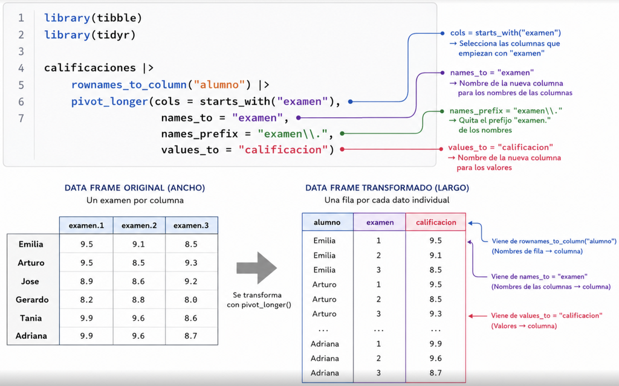

Ejecutemos el código:

```r
rownames_to_column(calificaciones, "alumno") %>%
  pivot_longer(
  cols = starts_with("examen"),
  names_to = "examen",
  names_prefix = "examen\\.",
  values_to = "calificacion"
)
```

```
## # A tibble: 18 × 3
##    alumno  examen calificacion
##    <chr>   <chr>         <dbl>
##  1 Emilia  1               9.5
##  2 Emilia  2               9.1
##  3 Emilia  3               8.5
##  4 Arturo  1               9.5
##  5 Arturo  2               8.5
##  6 Arturo  3               9.3
##  7 Jose    1               8.9
##  8 Jose    2               8.6
##  9 Jose    3               9.2
## 10 Gerardo 1               8.2
## 11 Gerardo 2               8.8
## 12 Gerardo 3               8
## 13 Tania   1               9.9
## 14 Tania   2               9.6
## 15 Tania   3               8.6
## 16 Adriana 1               9.9
## 17 Adriana 2               9.6
## 18 Adriana 3               8.7
```

Listo :). Continuemos con la siguiente parte de nuestra gráfica.

#### aesthetics

Una vez organizado nuestro data frame definamos las variables que queremos explorar, por ejemplo, el peso de los organismos en la columna **bodywt** y el total de horas de sueño en la columna **sleep_total**. Esta información se incluye en el comando aes(). En general, la información mínima necesaria para la sección **aesthetics** es indicar el eje x y el eje y:

```r
ggplot(data=msleep,aes(x=sleep_total,y=bodywt))
```

Nota que sólo indicamos el nombre de la columna porque ya indicamos el dataset en **data**. ¡Cuida que el nombre de la columna sea idéntico al de tu data frame! Más adelante exploraremos otras opciones que podemos definir dentro de aes().

#### geometry

Ahora que sabemos qué variables incluir en la gráfica, toca preguntarnos ¿qué tipo de gráfico requiero? Esto se define en la sección **geometry** y existe un comando distinto para cada tipo de gráfico. Por ahora elijamos una opción simple y construyamos un gráfico de puntos con geom_point():

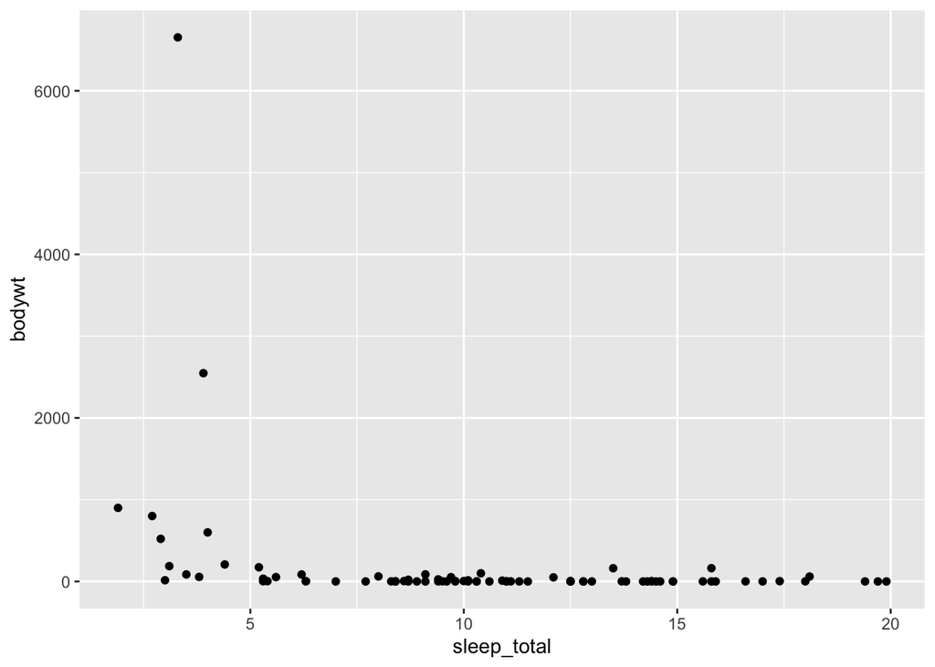

```r
ggplot(data=msleep, aes(x=sleep_total, y=bodywt)) + geom_point()
```

¡Felicidades! Acabas de crear tu primer gráfico con ggplot2 :).

Una buena práctica es visualizar en papel la gráfica que quieres construir, con el mayor detalle posible, aún antes de abrir R. Esto te ayudará a que la construcción de tu comando ggplot sea más intuitivo.

### Editando las partes del gráfico

Tras los argumentos básicos podemos agregar otros para modificar nuestro gráfico. Por ejemplo, podemos cambiar el color de los puntos con el argumento **color** dentro de la sección **geometry**:

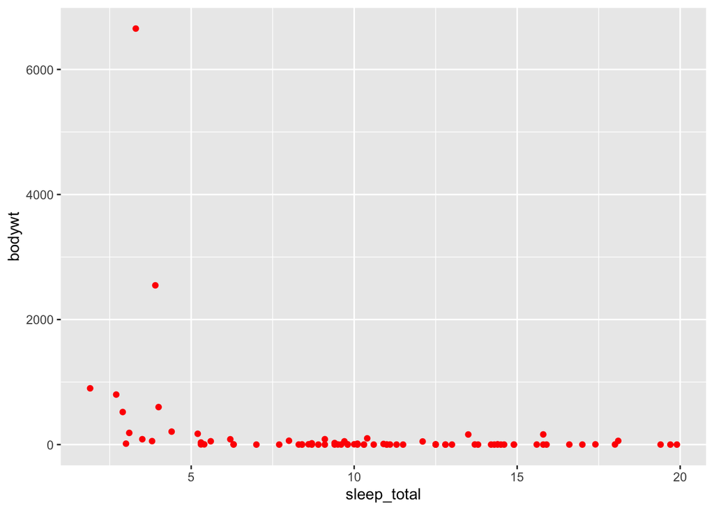

```r
ggplot(data=msleep, aes(x=sleep_total, y=bodywt)) + geom_point(color="red")
```

Nota que cambió el color de TODOS los puntos. Otros parámetros que podemos cambiar son **shape** y **size**:

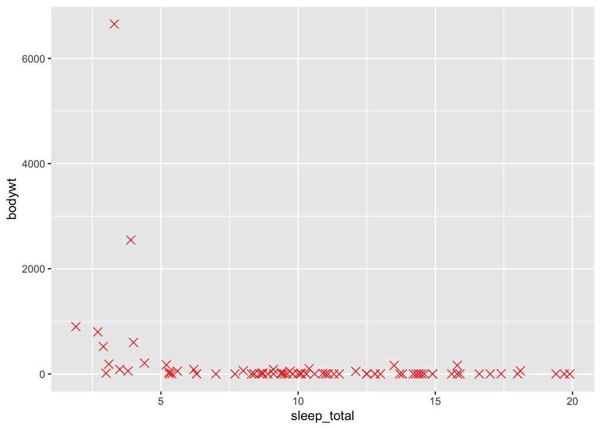

```r
ggplot(data=msleep, aes(x=sleep_total, y=bodywt)) + geom_point(color="red",shape=4,size=3)
```

El tamaño estándar es 1, cualquier valor mayor a 1 agrandará la forma, mientras que valores menores a 1 disminuirán su tamaño.

Nota que la forma la indicamos con un valor numérico. R contiene una guía interna de formas que pueden ser descritas de forma numérica y que puedes consultar [aquí](https://github.com/dledezma/curso_R/blob/master/pch.png).

Hasta ahora hemos cambiado el color, la forma y el tamaño de TODOS los puntos, pero estas variaciones pueden también describir otras variables de nuestros datos que pueden ayudar a la interpretación del gráfico. Por ejemplo, ¿los valores altos de masa corporal suelen agrupar dietas específicas? Para responder esta pregunta colorearemos los puntos de forma que reflejen la variable **vore**, que describe si los organismos son herbívoros, carnívoros u omnívoros.

Recuerda que las variables a graficar se definen en la sección **aesthetics**, dentro del comando aes():

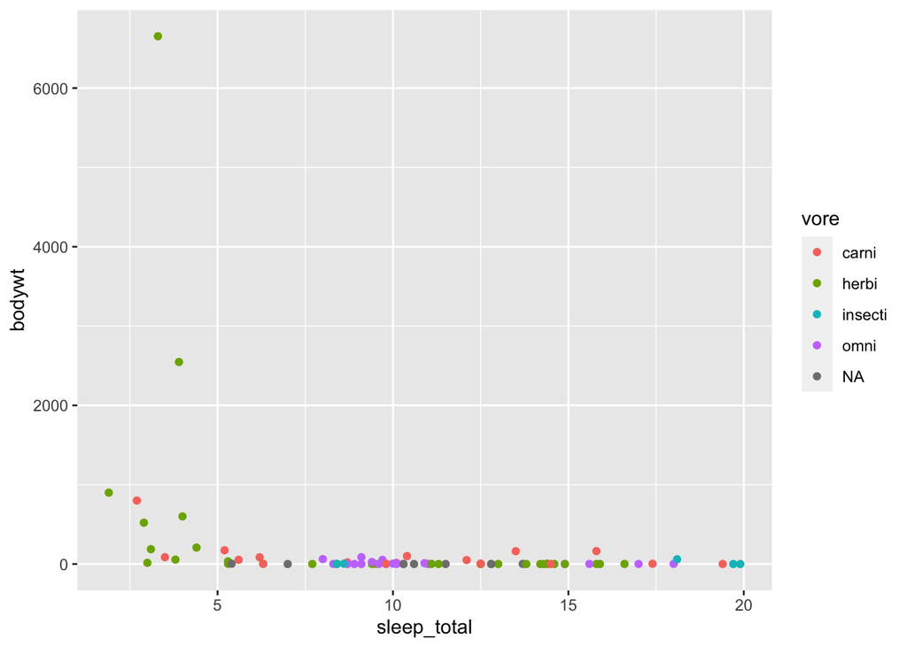

```r
ggplot(data=msleep, aes(x=sleep_total, y=bodywt, color=vore)) + geom_point()
```

Observa la diferencia entre definir el color dentro de **aesthetics** versus en **geometry**.

También puedes definir la forma de acuerdo a una variable:

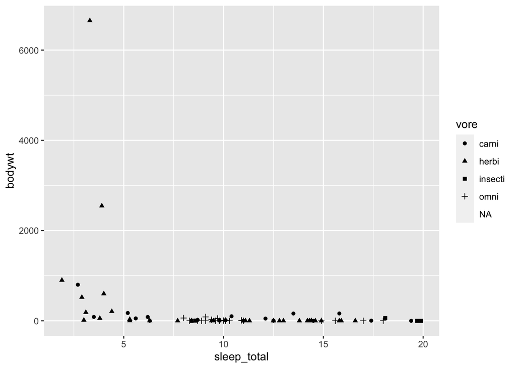

```r
ggplot(data=msleep, aes(x=sleep_total, y=bodywt, shape=vore)) + geom_point()
```

O combinar más de una variable:

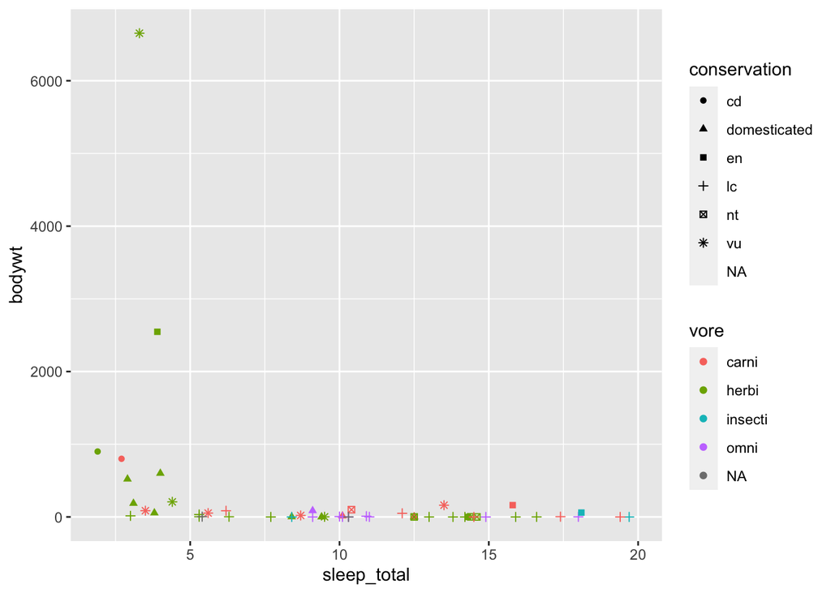

```r
ggplot(data=msleep, aes(x=sleep_total, y=bodywt, color=vore, shape=conservation)) + geom_point()
```

Existen otros comandos que podemos agregar para editar otras partes del gráfico, por ejemplo los nombres de los ejes, títulos, subtítulos y pies de figura con labs():

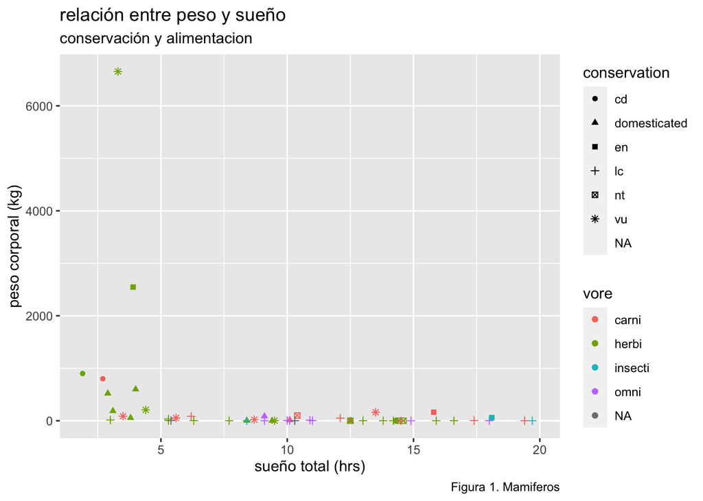

```r
ggplot(data=msleep, aes(x=sleep_total, y=bodywt, color=vore, shape=conservation)) + geom_point() + labs(x="sueño total (hrs)",y="peso corporal (kg)", title="relación entre peso y sueño", subtitle="conservación y alimentacion", caption="Figura 1. Mamiferos")
```

Conforme vamos editando partes de la gráfica, los comandos de ggplot pueden tornarse muy largos. Existen dos formas de organizarlos en más de una línea:

1. Cortando el comando TRAS un signo “**+**” y agregando el resto del comando en la siguiente línea:

```r
ggplot(data=msleep, aes(x=sleep_total, y=bodywt, color=vore, shape=conservation)) +
  geom_point() +
  labs(x="sueño total (hrs)",y="peso corporal (kg)", title="relación entre peso y sueño", subtitle="conservación y alimentacion", caption="Figura 1. Mamiferos")
```

2. Asignando la gráfica a un objeto y agregando capas paso a paso, sobrescribiendo el objeto. En cada capa que se agregue es necesario cerrar todos los paréntesis. Para desplegar el gráfico es suficiente con llamar al objeto:

```r
plot <- ggplot(data=msleep, aes(x=sleep_total, y=bodywt, color=vore, shape=conservation))
plot <- plot + geom_point()
plot <- plot + labs(x=“sueño total (hrs)”, y=“peso corporal (kg)”)
plot
```

### ¿Cómo elegir el tipo de gráfico adecuado?

Hasta ahora hemos hecho gráficas de puntos con geom_point(), pero existen muchas otras opciones de **geometry** que puedes encontrar [aquí](https://ggplot2.tidyverse.org/reference/).

Como ya se mencionó antes, parte de hacer una gráfica es tener claro el producto final antes d eempezar a programar. Para esto es es útil comenzar con 3 preguntas:

1. ¿Qué variables de mi dataset voy a graficar?
2. ¿Qué tipo de variables son?
3. ¿Cuál es el mensaje que quiero comunicar?

La primera respuesta depende enteramente de la intención de tu análisis. Para la segunda hay que identificar si tus variables son continuas (expresadas en términos cuantitativos) o discretas (expresadas con valores categóricos). Clasifiquemos las variables de **msleep**:

| Tipo | Variable | Descripcion |
| --- | --- | --- |
| discreta | name | common name |
| discreta | genus | taxonomic rank |
| discreta | vore | carnivore, omnivore or hervibore |
| discreta | order | taxonomic rank |
| discreta | conservation | the conservation status of the mammal |
| continua | sleep_total | total amount of sleep, in hours |
| continua | sleep_rem | rem sleep, in hours |
| continua | sleep_cycle | length of sleep cycle, in hours |
| continua | awake | amount of time spent awake, in hours |
| continua | brainwt | brain weight in kilograms |
| continua | bodywt | body weight in kilograms |

#### 1 variable discreta - geom_bar()

geom_bar() indica la ocurrencia de cada tipo de valor en forma de columnas. Nota que realiza las cuentas internamente y sólo recibe los datos crudos.

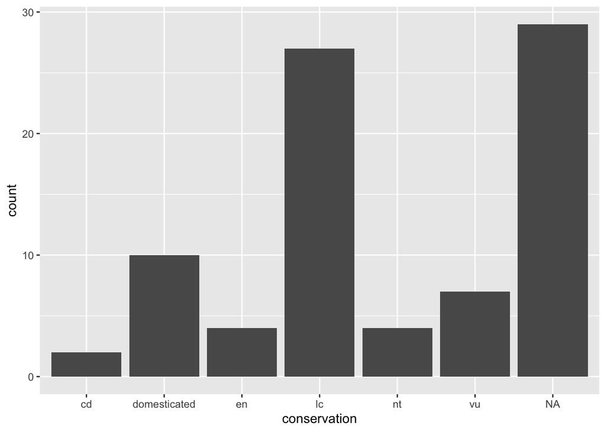

```r
ggplot(data=msleep, aes(conservation)) + geom_bar()
```

#### 1 variable continua - geom_histogram()

geom_histogram() indica la ocurrencia de cada tipo de valor a lo largo del eje X. Al igual que geom_bar(), realiza las cuentas internamente.

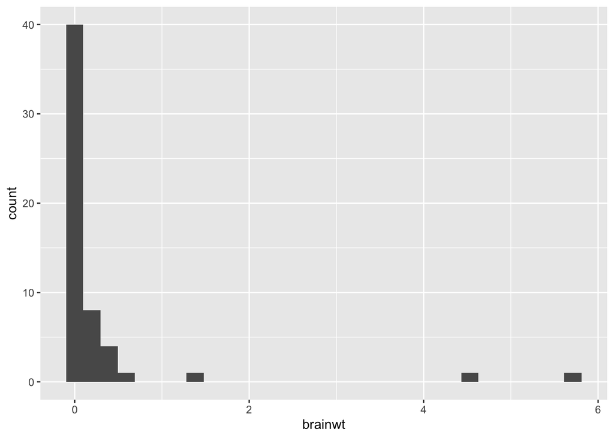

```r
ggplot(data=msleep, aes(brainwt)) + geom_histogram()
```

Cada comando **geometry** tiene sus propios argumentos permitidos. Utiliza el argumento **binwidth** dentro de geom_histogram() y descubre qué hace:

```r
ggplot(data=msleep, aes(brainwt)) + geom_histogram(binwidth=1)
```

#### 2 variables continuas - geom_point()

El mismo **geometry** que hemos usado anteriormente:

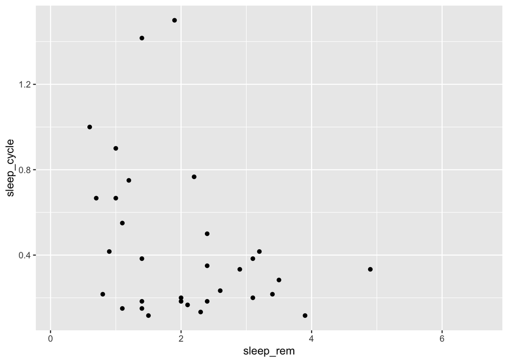

```r
ggplot(data=msleep, aes(x=sleep_rem,y=sleep_cycle)) + geom_point()
```

#### 2 variables continuas - geom_smooth()

Este **geometry** calcula la tendencia de tus datos y el intervalo de confianza del 95%. El método para calcular la tendencia puede ser modificado con el argumento **method**:

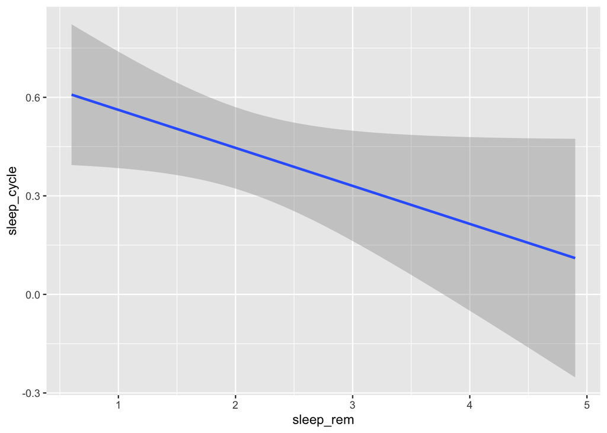

```r
ggplot(data=msleep, aes(x=sleep_rem,y=sleep_cycle)) + geom_smooth(method=lm)
```

Para los gráficos que indican tendencias o métricas de los datos puede ser útil mostrar al mismo tiempo los datos crudos. Esto se logra fácilmente agregando ambos **geometry** al mismo gráfico:

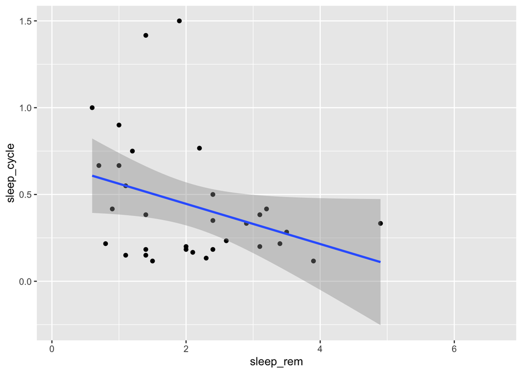

```r
ggplot(data=msleep, aes(x=sleep_rem,y=sleep_cycle)) + geom_point() + geom_smooth(method=lm)
```

Nota que el orden importa. Cada llamada a **geometry** crea una nueva capa en lo que se conoce como “modelo de pintor”. Es decir, cada capa se va construyendo una encima de la otra. El comando **geometry** que llames al principio quedará al fondo, mientras que el que llames al final quedará “pintado” sobre el resto como una pintura al óleo.

#### 2 variables discretas - geom_count()

Indica la frecuencia de cada variable utilizando círculos.

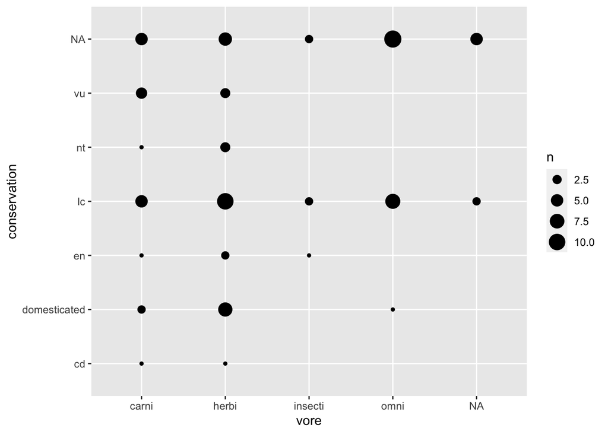

```r
ggplot(data=msleep, aes(x=vore,y=conservation)) + geom_count()
```

#### 2 variables discretas - geom_jitter()

Indica la frecuencia de cada variable utilizando puntos individuales. Puede ser más clara que geom_count() cuando las diferencias entre grupos son muy grandes.

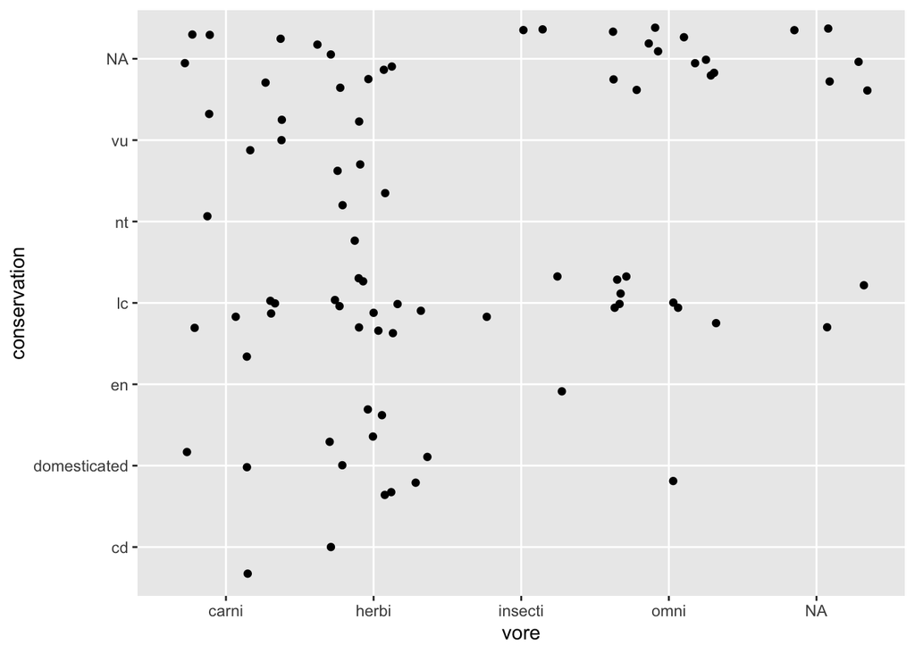

```r
ggplot(data=msleep, aes(x=vore,y=conservation)) + geom_jitter()
```

geom_jitter() internamente evita que cualquier par de puntos en la gráfica se sobrelapen, lo que da mayor claridad que por ejemplo geom_point() cuando se tienen varios puntos en la misma coordenada. Sólo es importante notar que cada llamada a geom_jitter() generará un gráfico ligeramente diferente.

#### 1 variables discreta y 1 variable continua - geom_boxplot()

Indica los percentiles 25, 50 y 75 con una caja rectangular, así como el rango intercuartil y los outliers.

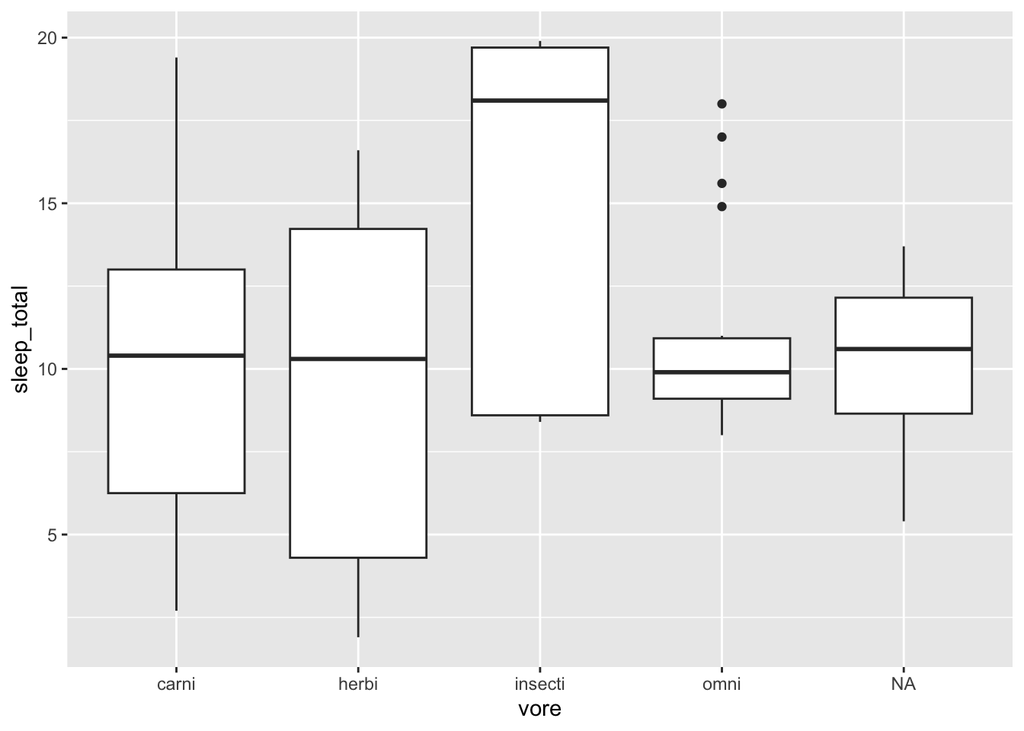

```r
ggplot(data=msleep, aes(x=vore,y=sleep_total)) + geom_boxplot()
```

#### 1 variables discreta y 1 variable continua - geom_violin()

Indica la forma de la distribución a lo largo de los valores del eje Y.

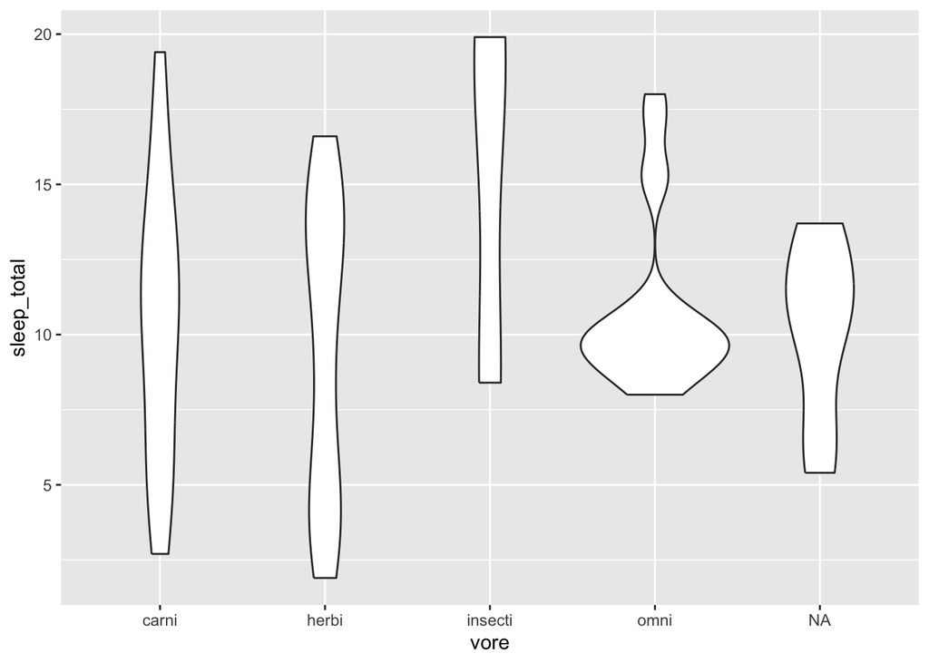

```r
ggplot(data=msleep, aes(x=vore,y=sleep_total)) + geom_violin()
```

#### 1 variables discreta y 1 variable continua - geom_dotplot()

Similar a geom_violin() en que indica la forma de la distribución a lo largo de los valores del eje Y, pero lo hace con puntos individuales. Puede ser poco informativa cuando se tienen demasiados datos.

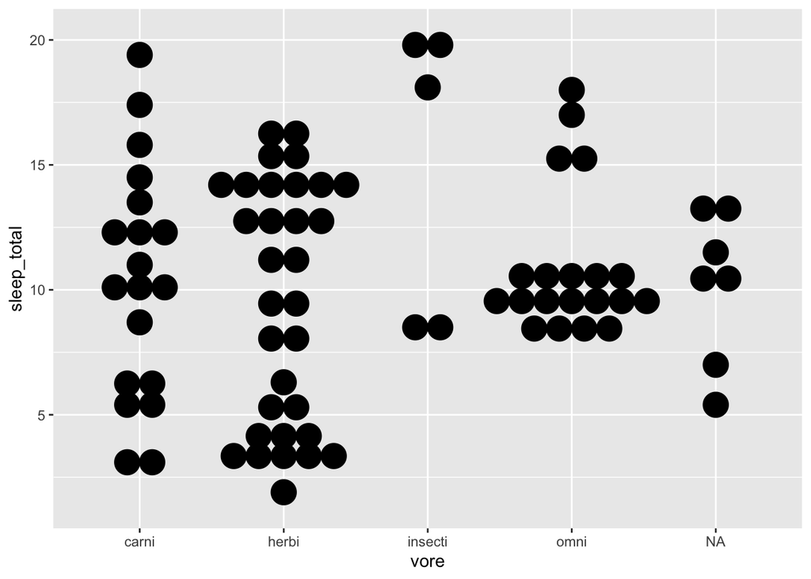

```r
ggplot(data=msleep, aes(x=vore,y=sleep_total)) + geom_dotplot(binaxis="y",stackdir="center",binwidth=1)
```

Es posible cambiar el eje de referencia con el argumento **binaxis=“x”**. **stackdir=center** indica que los puntos deben estar alineados en el centro de la categoría en el eje x. Descubre lo que sucede al eliminarlo:

```r
ggplot(data=msleep, aes(x=vore,y=sleep_total)) + geom_dotplot(binaxis="y",binwidth=1)
```

#### 2 variables discretas y 1 variable continua - geom_tile()

También conocido como mapa de calor o *heatmap*, geom_tile() utiliza color para indicar la variable continua en todas las combinaciones de pares de las variables discretas:

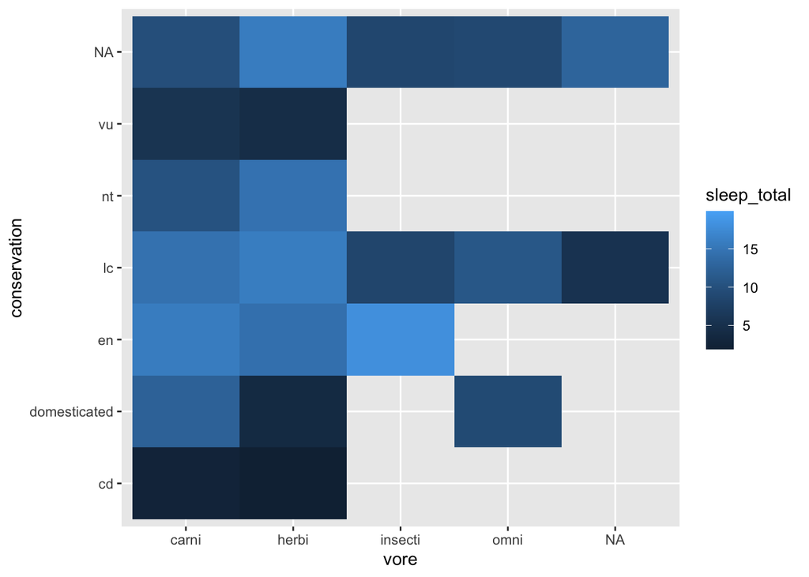

```r
ggplot(data=msleep, aes(x=vore,y=conservation, fill=sleep_total)) + geom_tile()
```

Si en tus datos existieran más de un valor para cada posición del *heatmap*, sólo se visualizará el último en el data frame, pues los otros quedarán graficados “debajo”.

### ¿Cuál es el mensaje que quiero comunicar?

Lo que hemos visto hasta ahora es suficiente para explorar nuestros datos. Cuando decidimos hacer un gráfico para describir nuestros datos a alguien más, la pregunta sobre qué mensaje queremos comunicar se torna más importante. Algunos mensajes comunes son:

1. Mostrar la distribución general de nuestros datos.
2. Mostrar si existe relación entre dos o más variables.
3. Resaltar casos particulares.

En estos casos, lo que se necesita resaltar en el gráfico es:

1. La forma de la distribución de los datos.
2. La presencia/ausencia de la relación.
3. La tendencia de los datos y aquellos que la escapan.

Como regla general, si descubres que tienes más de un mensaje que comunicar, entonces necesitas más de un gráfico.

Para enfatizar o resaltar una propiedad en un gráfico podemos usar los colores y las formas. Observa la diferencia entre las siguientes dos gráficas.

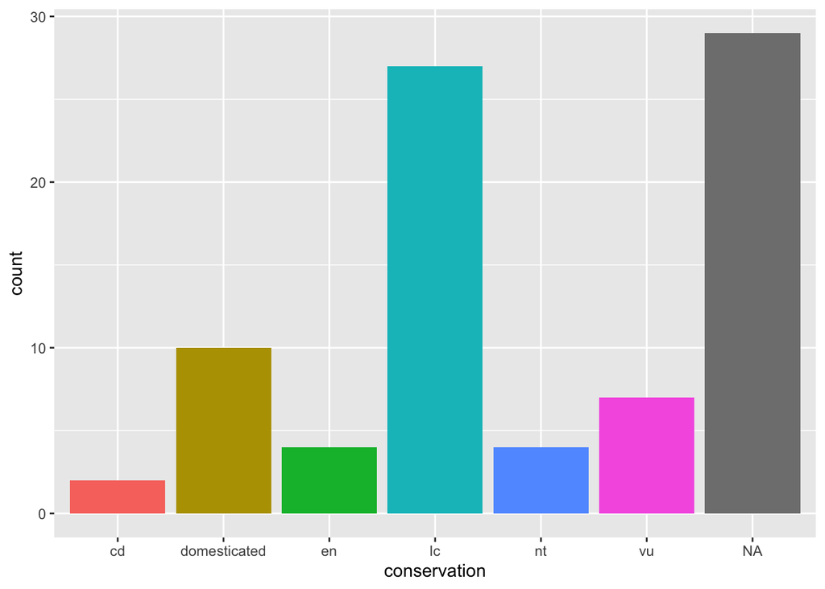

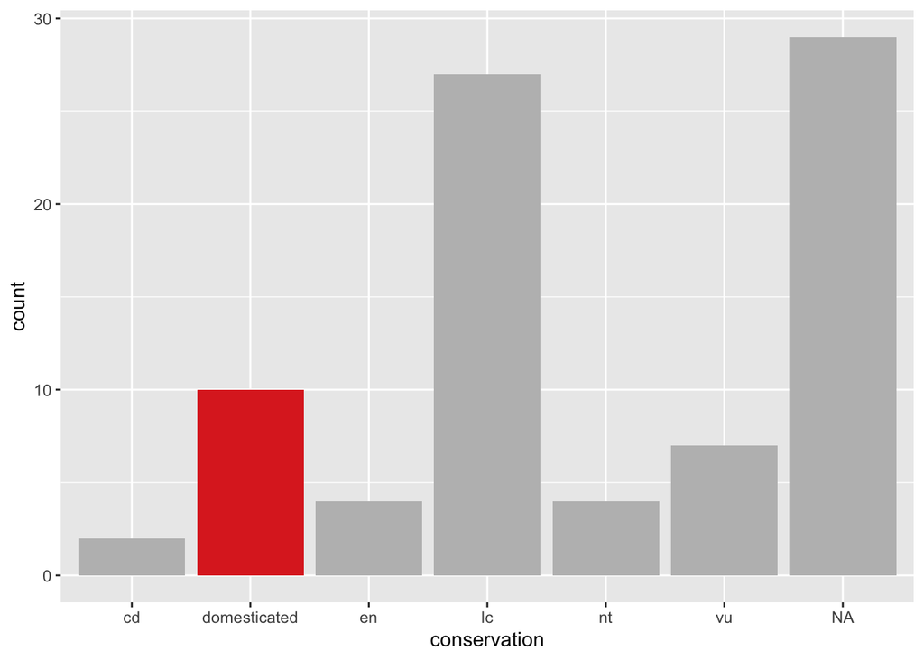

¿De qué crees que trate el artículo de la primera? ¿Y de la segunda?

La segunda gráfica resalta mejor a los animales domesticados. Al mostrarla, la atención de tu audiencia se enfocará inmediatamente en la barra roja y no tanto en las diferencias entre las otras barras, evitando que la atención se disperse. Es el equivalente gráfico de llevarlos de la mano a lo que es relevante en la gráfica. Por otro lado, requiere un poco más de esfuerzo construirla.

Comencemos por generar la gráfica colorida:

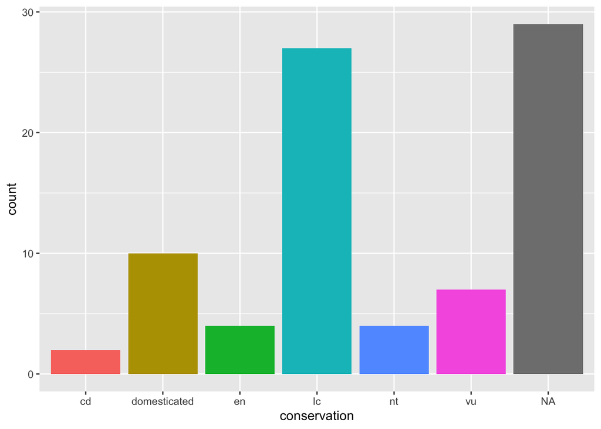

```r
ggplot(data=msleep, aes(conservation, fill=conservation)) + geom_bar() + theme(legend.position="none")
```

Utilizamos **fill=conservation** para indicar que cada barra se llenará (*fill*) con un color que también mapeará a la variable **conservation**. **theme(legend.position=“none”)** omite la leyenda de colores pues, en este caso, esa información es redundante con el eje X.

Este código nos recuerda que es posible definir los colores de acuerdo a una variable, i.e. una columna de nuestro dataset. Para definir los colores a nuestro gusto, sólo es necesario crear esa columna.

Pero alto, recuerda que antes de comenzar a utilizar código de R es necesario tener en papel la gráfica que queremos lograr y para ello debes definir tus colores. En el ejemplo utilizamos rojo y gris, pero puedes encontrar muchos más colores en la página de [colorbrewer](https://colorbrewer2.org) o en los [colores default de R](https://github.com/dledezma/curso_R/blob/master/Rcolor.pdf). Una vez que los hayas elegido, guarda el código HEX o el nombre del color en R.

Ahora sí, creemos la nueva variable.

```r
#Creamos una copia de msleep aara no alterar el objeto original
msleep.2 <- msleep
#Creamos un vector del mismo tamaño con color default
n.color <- rep("gris",dim(msleep.2)[1])
#Agregamos nuestro vector como una variable (columna) nueva
msleep.2 <- cbind(msleep.2,n.color)
#Obtenemos el índice de los animales domesticados
index <- which(msleep.2$conservation=="domesticated")
#Cambiamos a rojo el valor de los animales domesticados
msleep.2$n.color[index] <- "rojo"
#Comprobamos que exista nuestra nueva columna
msleep.2[1:5,c(1,5,12)]
```

```
##                         name conservation n.color
## 1                    Cheetah           lc    gris
## 2                 Owl monkey         <NA>    gris
## 3            Mountain beaver           nt    gris
## 4 Greater short-tailed shrew           lc    gris
## 5                        Cow domesticated    rojo
```

Grafiquemos mapeando el color de relleno de las barras a nuestra nueva columna.

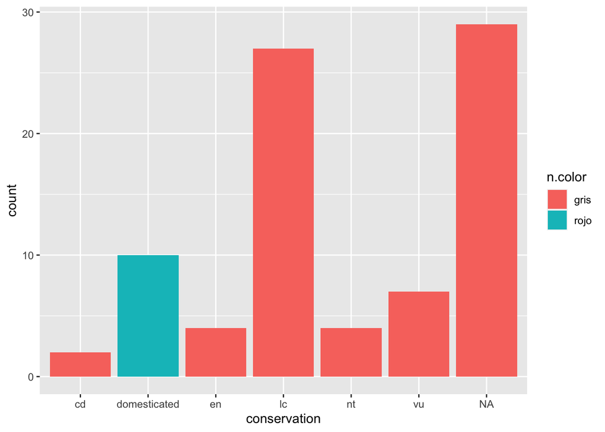

```r
ggplot(data=msleep.2, aes(conservation, fill=n.color)) + geom_bar()
```

¿Qué pasó? La nueva columna sólo indica grupos en los datos (gris o rojo/*domesticated* o otros), pero el texto no se traduce en los colores que se utilizarán en la gráfica. Esto quiere decir que podemos utilizar cualquier texto para indicar los grupos, pero es útil usar los colores para evitar confusiones. Para definir los colores usamos el código HEX (o los nombres de colores en R) y el comando **scale_fill_manual()**:

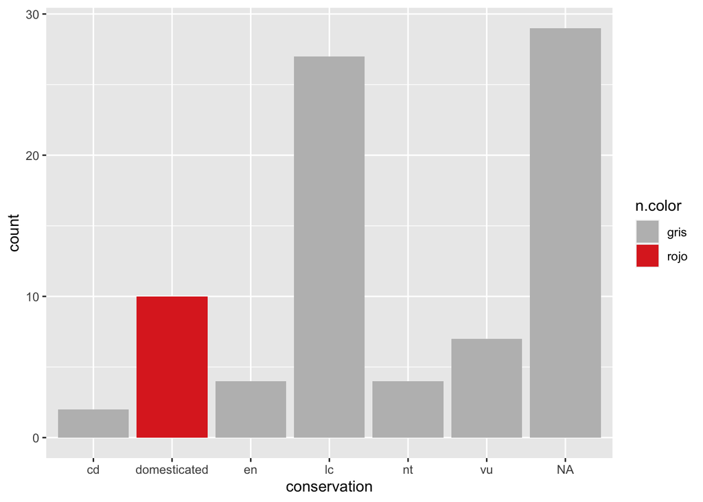

```r
ggplot(data=msleep.2, aes(conservation, fill=n.color)) + geom_bar() + scale_fill_manual(values=c("#bdbdbd","#de2d26"))
```

Observa lo que sucede si inviertes el órden de los colores:

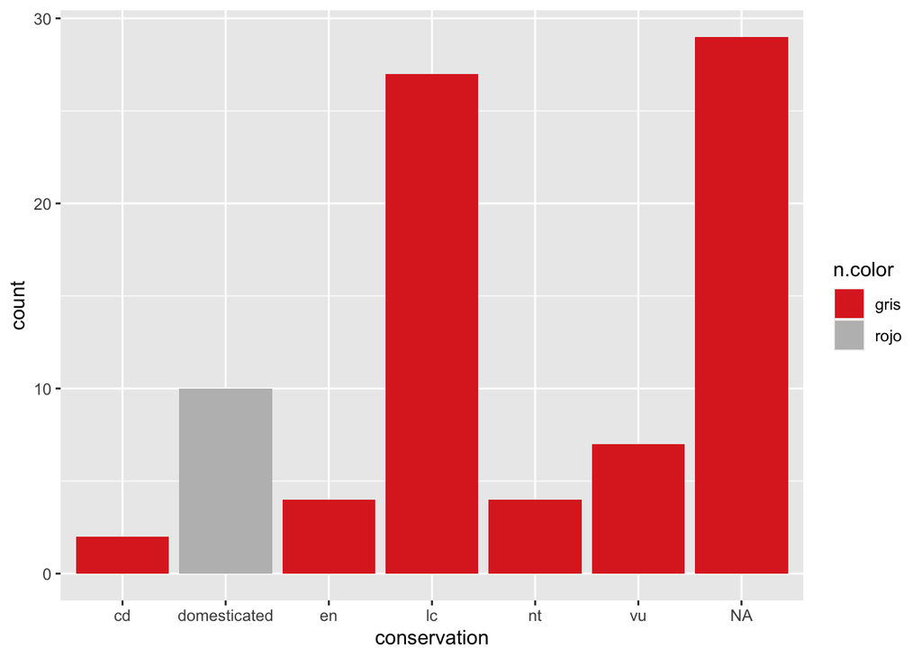

```r
ggplot(data=msleep.2, aes(conservation, fill=n.color)) + geom_bar() + scale_fill_manual(values=c("#de2d26","#bdbdbd"))
```

La leyenda es útil para ti, inútil para tu audiencia. Puedes removerla como vimos antes con **theme(legend.position=“none”)** o directamente dentro de **scale_fill_manual()**:

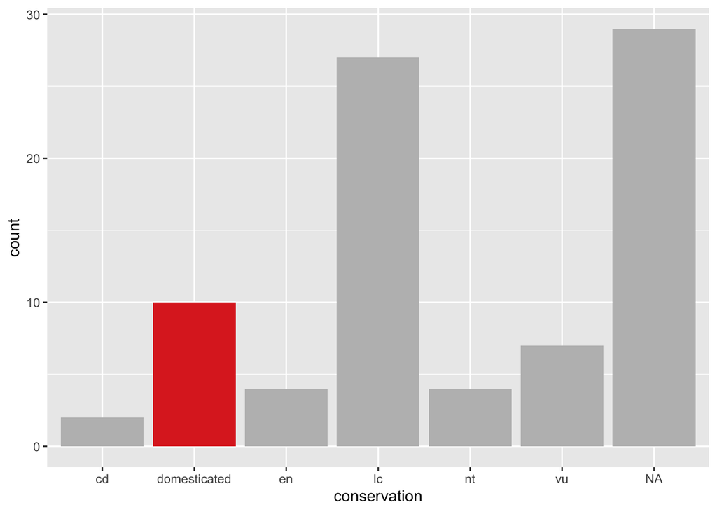

```r
ggplot(data=msleep.2, aes(conservation, fill=n.color)) + geom_bar() + scale_fill_manual(values=c("#bdbdbd","#de2d26"), guide="none")
```

Si los animales domesticados son de tu interés, es posible que quieras resaltarlos en otros gráficos. Para ello puedes seguir utilizando la columna que creamos.

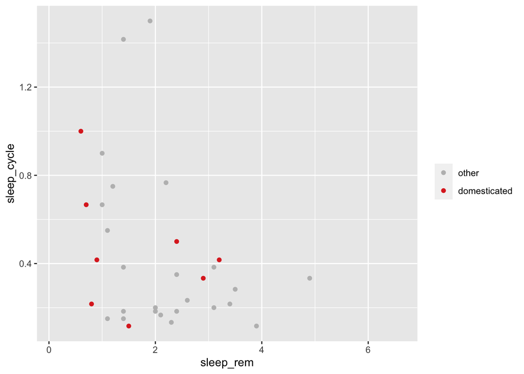

```r
ggplot(data=msleep.2, aes(x=sleep_rem,y=sleep_cycle, color=n.color)) + geom_point() + scale_color_manual(values=c("#bdbdbd","#de2d26"),labels=c("other","domesticated"),name="")
```

Observa que esta vez utilizamos el comando **scale_color_manual()** en ligar de **color_fill_manual()**. En general *fill* se utiliza en barras y *color* en líneas y puntos. También nota que en este gráfico la leyenda sí es informativa. El parámetro **labels** dentro de **scale_color_manual()** define el texto que describe cada color en la leyenda. Ten cuidado de revisar que no estén invertidos, pues el órden importa. Finalmente, eliminamos el título de la leyenda usando **name=““**.

Para crear un gráfico de publicación puedes editar el fondo utilizando **theme_classic()** y editando los nombres de tus ejes

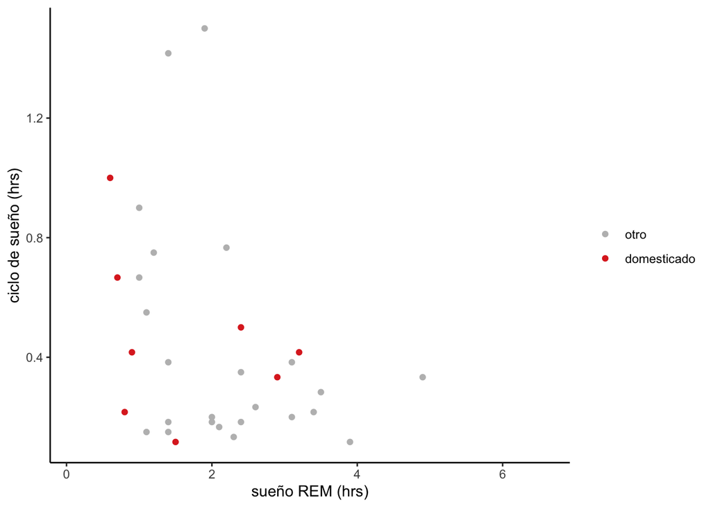

```r
ggplot(data=msleep.2, aes(x=sleep_rem,y=sleep_cycle, color=n.color)) + geom_point() + scale_color_manual(values=c("#bdbdbd","#de2d26"),labels=c("otro","domesticado"),name="") + theme_classic() + labs(x="sueño REM (hrs)", y="ciclo de sueño (hrs)")
```

### Consejos generales al graficar

1. Tus ejes siempre deben iniciar en 0 a menos de que estés mostrando datos que pasaron un valor de corte.
2. Evita utilizar gráficas de pie para más de 4 categorías, pues es difícil percibir las diferencias. Recuerda que la suma de todas las categorías en el pie debe ser siempre 100%.
3. En un histograma sólo corta el eje Y si todas tus barras están por encima del corte, de otra forma las barras ya no serán comparables. Al apilar barras cuida que todas tengan las mismas categorías.
4. Evita incluir información que no sea relevante para el mensaje que pretendes comunicar. Entre más simple sea tu gráfica, más fácil será comprenderla.
5. Evita los nombres muy largos en el eje X. Si fueran necesarios, gira la gráfica para que queden en el eje Y y sean más fáciles de leer.
6. Procura ser sistemática en tus gráficos, evita eliminar categorías que contradicen tu hipótesis o combinar variables de formas engañosas.
7. Sé consciente de los sesgos que incluyen tus gráficos.
8. Evita combinar variables en el mismo gráfico que requieran ejes Y distintos. Es engañoso y difícil de interpretar objetivamente.

##### Recursos para aprender màs sobre ggplot2 y visualización de datos

[Storytelling with Data: A Data Visualization Guide for Business Professionals](https://www.wiley.com/en-us/Storytelling+with+Data%3A+A+Data+Visualization+Guide+for+Business+Professionals-p-9781119002253#download-product-flyer)

[ggplot2: Elegant Graphics for Data Analysis](https://ggplot2-book.org/)

[ggplot2 cheat sheet](https://rstudio.github.io/cheatsheets/data-visualization.pdf)

Daniela Ledezma Tejeida, 2024. Material bajo una licencia CC BY-NC-ND de Creative Commons. Reportar errores o sugerencias via [forma de contacto](https://sites.google.com/ccg.unam.mx/ledezma-tejeida-lab/contact?authuser=0).